# Part 1 - Explore

# Load packages

```r
# Load tidyvese package package
library(tidyverse)
```

# Chapter 1 - Data visualization using ggplot2

## 1- Introduction

### 1.1 - Notes

No real notes for this section. Book only talks about prerequisites for running R and excreta.

### 1.2 - Exercises

There is no exercises.

## 2 - First steps

### 2.1 - Notes

We are using the MPG data set. This comes with the tidyverse package.

A standard graphing template is as follows.

```r
ggplot(data = <DATA>) +
  <GEOM_FUNCTION>(mapping = aes(<MAPPINGS>))
```

### 2.2 - Exercises

#### **Question 1 - Run plotting on mpg. What do you see?**

**Answer:** Doing this we see an empty graph. I need to define what I want to view.

**Output:**

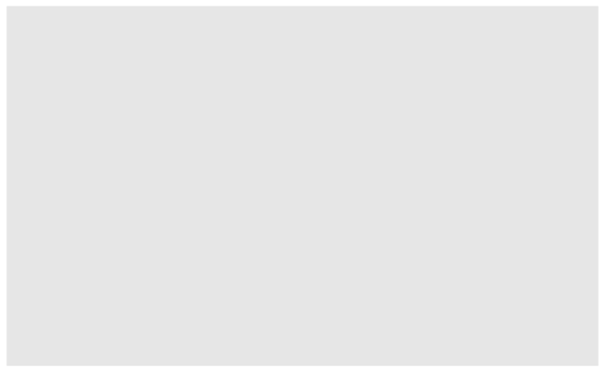

```r
ggplot (data = mpg)
```

#### **Question 2 - How many rows and columns are in mpg?**

**Answer:** I can find this using the `str()` (base R), `glimpse()` (tidyverse), or more specifically `nrow()` and `ncol()`. Or just simply writing the data in the console.

**Output:**

```r
str(mpg)
```

```
tibble [234 × 11] (S3: tbl_df/tbl/data.frame)
 $ manufacturer: chr [1:234] "audi" "audi" "audi" "audi" ...
 $ model       : chr [1:234] "a4" "a4" "a4" "a4" ...
 $ displ       : num [1:234] 1.8 1.8 2 2 2.8 2.8 3.1 1.8 1.8 2 ...
 $ year        : int [1:234] 1999 1999 2008 2008 1999 1999 2008 1999 1999 2008 ...
 $ cyl         : int [1:234] 4 4 4 4 6 6 6 4 4 4 ...
 $ trans       : chr [1:234] "auto(l5)" "manual(m5)" "manual(m6)" "auto(av)" ...
 $ drv         : chr [1:234] "f" "f" "f" "f" ...
 $ cty         : int [1:234] 18 21 20 21 16 18 18 18 16 20 ...
 $ hwy         : int [1:234] 29 29 31 30 26 26 27 26 25 28 ...
 $ fl          : chr [1:234] "p" "p" "p" "p" ...
 $ class       : chr [1:234] "compact" "compact" "compact" "compact" ...
```

```r
glimpse(mpg)
```

```
Rows: 234
Columns: 11
$ manufacturer <chr> "audi", "audi", "audi", "audi", "audi", "audi", "audi", "audi", "audi", "audi", "aud…
$ model        <chr> "a4", "a4", "a4", "a4", "a4", "a4", "a4", "a4 quattro", "a4 quattro", "a4 quattro", …
$ displ        <dbl> 1.8, 1.8, 2.0, 2.0, 2.8, 2.8, 3.1, 1.8, 1.8, 2.0, 2.0, 2.8, 2.8, 3.1, 3.1, 2.8, 3.1,…
$ year         <int> 1999, 1999, 2008, 2008, 1999, 1999, 2008, 1999, 1999, 2008, 2008, 1999, 1999, 2008, …
$ cyl          <int> 4, 4, 4, 4, 6, 6, 6, 4, 4, 4, 4, 6, 6, 6, 6, 6, 6, 8, 8, 8, 8, 8, 8, 8, 8, 8, 8, 8, …
$ trans        <chr> "auto(l5)", "manual(m5)", "manual(m6)", "auto(av)", "auto(l5)", "manual(m5)", "auto(…
$ drv          <chr> "f", "f", "f", "f", "f", "f", "f", "4", "4", "4", "4", "4", "4", "4", "4", "4", "4",…
$ cty          <int> 18, 21, 20, 21, 16, 18, 18, 18, 16, 20, 19, 15, 17, 17, 15, 15, 17, 16, 14, 11, 14, …
$ hwy          <int> 29, 29, 31, 30, 26, 26, 27, 26, 25, 28, 27, 25, 25, 25, 25, 24, 25, 23, 20, 15, 20, …
$ fl           <chr> "p", "p", "p", "p", "p", "p", "p", "p", "p", "p", "p", "p", "p", "p", "p", "p", "p",…
$ class        <chr> "compact", "compact", "compact", "compact", "compact", "compact", "compact", "compac…
```

```r
nrow(mpg)
```

```
[1] 234
```

```r
ncol(mpg)
```

```
[1] 11
```

```r
mpg
```

| manufacturer | model | displ | year | cyl | trans | drv | cty | hwy | fl | class |
| --- | --- | --- | --- | --- | --- | --- | --- | --- | --- | --- |
| audi | a4 | 1.8 | 1999 | 4 | auto(l5) | f | 18 | 29 | p | compact |
| audi | a4 | 1.8 | 1999 | 4 | manual(m5) | f | 21 | 29 | p | compact |
| audi | a4 | 2.0 | 2008 | 4 | manual(m6) | f | 20 | 31 | p | compact |
| audi | a4 | 2.0 | 2008 | 4 | auto(av) | f | 21 | 30 | p | compact |
| audi | a4 | 2.8 | 1999 | 6 | auto(l5) | f | 16 | 26 | p | compact |
| audi | a4 | 2.8 | 1999 | 6 | manual(m5) | f | 18 | 26 | p | compact |
| audi | a4 | 3.1 | 2008 | 6 | auto(av) | f | 18 | 27 | p | compact |
| audi | a4 quattro | 1.8 | 1999 | 4 | manual(m5) | 4 | 18 | 26 | p | compact |
| audi | a4 quattro | 1.8 | 1999 | 4 | auto(l5) | 4 | 16 | 25 | p | compact |
| audi | a4 quattro | 2.0 | 2008 | 4 | manual(m6) | 4 | 20 | 28 | p | compact |

[output cut: 224 more lines]

It is 234 rows and 11 columns.

#### **Question 3 - what does the dr variable describe?**

**Answer:** I can find out what the `dr` variable describes by looking trough the documentation for mpg.

**Output:**

```r
?mpg
```

The variable `drv` describes whether the car is (front wheel drive), r (rear wheel drive), or 4 (four wheel drive).

#### **Question 4 - make a scatter-plot of hwy vs cyl**

**Answer:** I can do that using `geom_point`, as seen below.

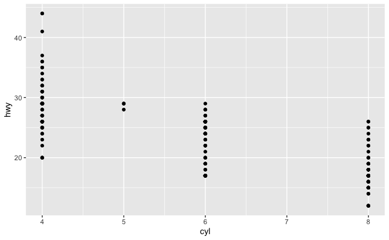

```r
ggplot(data = mpg) +
  geom_point(mapping = aes(x = cyl, y = hwy))
```

#### **Question 5 - What happens if you make a scatter-plot of class vs drv? Why is it not useful?**

**Answer:** See graph below for what happens. Such a graph is not useful as the type of wheel setup (`drv`) is not dependent on type of car.

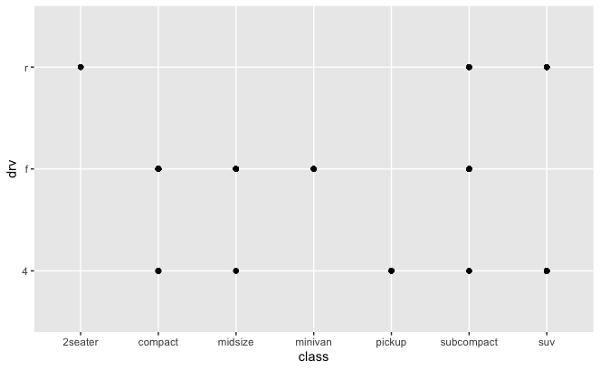

```r
ggplot(data = mpg) +
  geom_point(mapping = (aes(x = class, y = drv)))
```

## 3 - Aesthetic mappings

### 3.1 - Notes

Aesthetic mapping lets you highlight specific components of the data. Aesthetics includes things like **size**, **shape** and **color**. One can use aesthetic mapping like this.

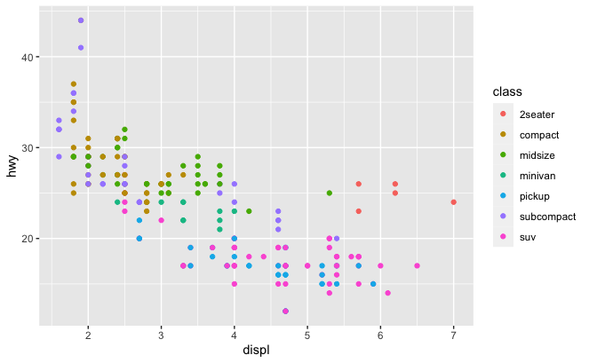

```r
ggplot(data = mpg) +
  geom_point(mapping = aes(x = displ, y = hwy, color = class))
```

Here is the same example, using size instead.

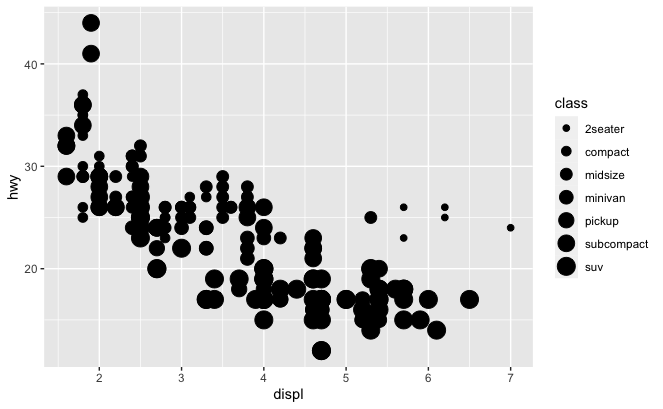

```r
ggplot(data = mpg) +
  geom_point(mapping = aes(x = displ, y = hwy, size = class))
```

This gives us a different aesthetic, however, in this case it is not advised as it is very difficult to differentiate different groups based on size. Other things we can map includes: alpha (transparency) and shape.

Furthermore, we can set aesthetics manually like this.

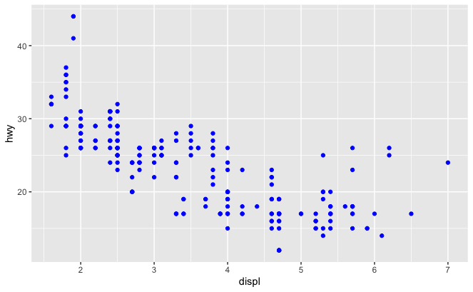

```r
ggplot(data = mpg) +
  geom_point(mapping = aes(x = displ, y = hwy), color = "blue")
```

You can look up information on the types of shapes that are available in R. There is a total of 25.

### 3.2 - Exercises

#### **Question 1 - What’s gone wrong with this code? Why are the points not blue?**

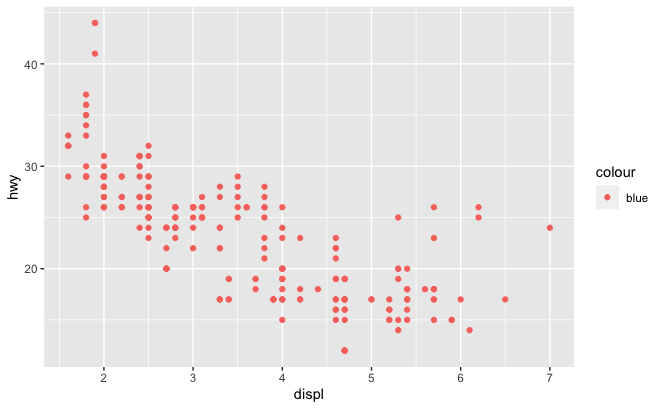

```r
ggplot(data = mpg) +
  geom_point(mapping = aes(x = displ, y = hwy, color = "blue"))
```

**Answer**: The point is not blue because the deceleration for blue points are inside the `aes` declaration. This creates a new variable in MPG called blue, which R attempts to color, first color being red.

#### **Question 2 - Which variables in mpg are categorical and continuous?**

**Answer:** One can sometimes figure this out by looking at the documentation.

```r
?mpg
```

In this specific case, it gives us nothing. Therefore, the next step would be to simply look at the data.

```r
mpg
```

| manufacturer | model | displ | year | cyl | trans | drv | cty | hwy | fl | class |
| --- | --- | --- | --- | --- | --- | --- | --- | --- | --- | --- |
| audi | a4 | 1.8 | 1999 | 4 | auto(l5) | f | 18 | 29 | p | compact |
| audi | a4 | 1.8 | 1999 | 4 | manual(m5) | f | 21 | 29 | p | compact |
| audi | a4 | 2.0 | 2008 | 4 | manual(m6) | f | 20 | 31 | p | compact |
| audi | a4 | 2.0 | 2008 | 4 | auto(av) | f | 21 | 30 | p | compact |
| audi | a4 | 2.8 | 1999 | 6 | auto(l5) | f | 16 | 26 | p | compact |
| audi | a4 | 2.8 | 1999 | 6 | manual(m5) | f | 18 | 26 | p | compact |
| audi | a4 | 3.1 | 2008 | 6 | auto(av) | f | 18 | 27 | p | compact |
| audi | a4 quattro | 1.8 | 1999 | 4 | manual(m5) | 4 | 18 | 26 | p | compact |
| audi | a4 quattro | 1.8 | 1999 | 4 | auto(l5) | 4 | 16 | 25 | p | compact |
| audi | a4 quattro | 2.0 | 2008 | 4 | manual(m6) | 4 | 20 | 28 | p | compact |

[output cut: 224 more lines]

While there is no certainty, usually columns coded as characters (`chr`) can function as categorical while numeric values (`int` and `dbl`) are continuous.

#### **Question 3 - Map a continuous variable to color, size, and shape and look how they behave compared to categorical values**

**Answer:**

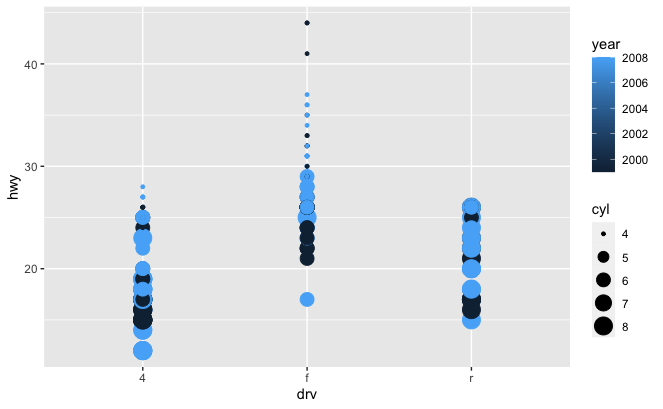

When mapping continuous variables to color, it creates a gradient when used with continuous variables. Size also work with continuous variables, however, is not as good and rather scales the variables instead of having discrete sizes.

Furthermore, a continuous variable cant be mapped to something like shapes, as there must then be a shape for each unique value.

#### **Question 4 - What happens if you map the same variable to multiple aesthetics?**

**Answer:**

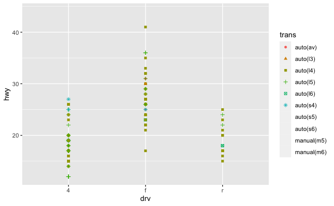

```r
ggplot(data = mpg) +
  geom_point(mapping = aes(x = drv, y = hwy, color = trans, shape = trans))
```

Both things are mapped, simple as that.

#### **Question 5 - What does the stroke aesthetic do? What shapes does it work with?**

I can see this by looking at the vignette for ggplot2.

```r
?geom_point
```

From this we learn that stroke can modify the width of the border of certain shapes (21 - 24).

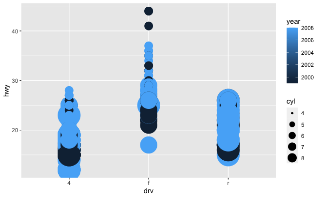

```r
ggplot(data = mpg) +
  geom_point(mapping = aes(x = drv, y = hwy, color = year, size = cyl, stroke = cyl))
```

It can also do this:

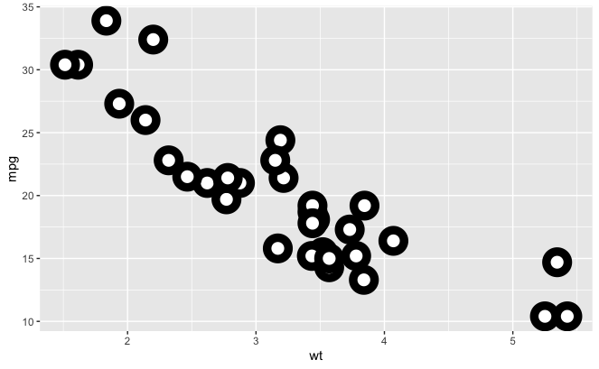

```r
ggplot(mtcars, aes(wt, mpg)) +
  geom_point(shape = 21, colour = "black", fill = "white", size = 5, stroke = 5)
```

#### **Question 6 - What happens if you map an aesthetic to something other than a variable name?**

**Answer:**

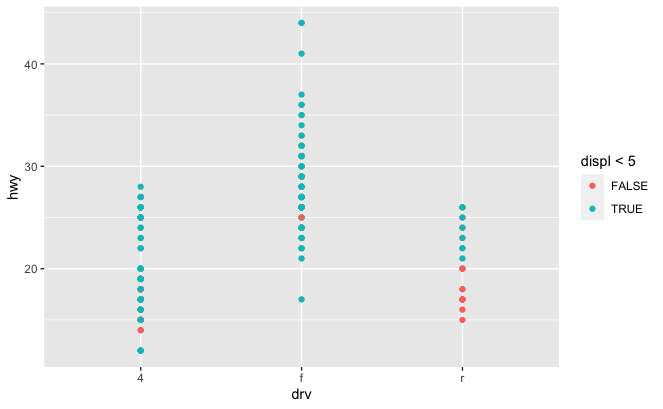

```r
ggplot(data = mpg) +
  geom_point(mapping = aes(x = drv, y = hwy, color = displ < 5))
```

Aesthetics can also be mapped to logical expressions.

## 4 - Facets

### 4.1 - Notes

One additional way to show your data is to split your plot into subplots, also called facets. Facets can be created using the `facet_wrap()` function. To pass a variable to `facet_wrap()` you need to cast a variable with a formula (~).

This can be done line this:

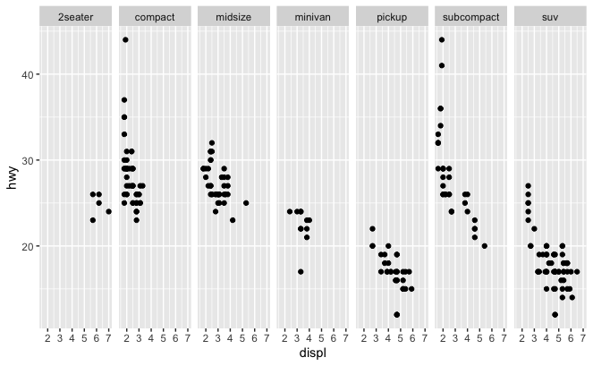

```r
ggplot(data = mpg) +
  geom_point(mapping = aes(x = displ, y = hwy)) +
  facet_wrap(~ class, nrow = 1)
```

It is also possible to facet a plot in combination with two variables using `facet_grid()`. This function creates a x and y axis, sort of like a heatmap.

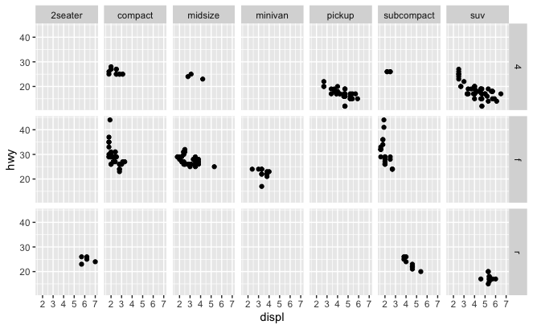

```r
ggplot(data = mpg) +
  geom_point(mapping = aes(x = displ, y = hwy)) +
  facet_grid(drv ~ class)
```

It is apparantly possible to make a `facet_grid()` into a `facet_wrap(nrow = 1)` by writing e.g., `facet_grid(. ~ cyl)`. I do however not see why would do this instead of a facet wrap. I would argue that a wrap is more readable.

### 4.2 - Exercises

#### **Question 1 - What happens if you facet on a continuous variable?**

**Answer:**

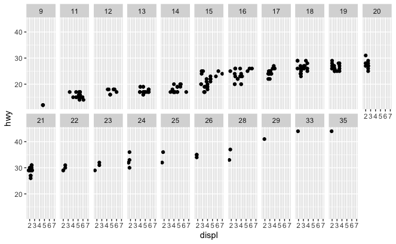

```r
ggplot(data = mpg) +
  geom_point(mapping = aes(x = displ, y = hwy)) +
  facet_wrap(~ cty, nrow = 2)
```

We get so many facets/subplots as there is unique values. So it is not smart.

#### **Question 2 - What do the empty cells in a plot with facet_grid(drv ~ cyl) mean? How do they relate to this plot?**

**Answer:**

Empty cells means that there are some `drv ~ cyl` combinations that have no values (hence empty).

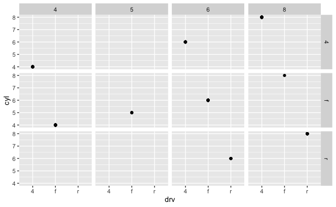

```r
ggplot(data = mpg) +
  geom_point(mapping = aes(x = drv, y = cyl)) +
  facet_grid(drv ~ cyl)
```

#### **Question 3 - What plots does the following code make? What does . do?**

**Answer:**

As I wrote in my notes, the . makes essentially a `facet_wrap()` with only one row or column. The `.` simply states that you do not want the facets in any dimensions.

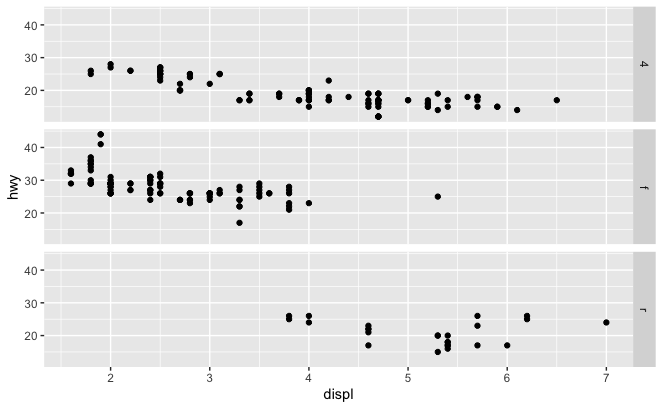

```r
ggplot(data = mpg) +
  geom_point(mapping = aes(x = displ, y = hwy)) +
  facet_grid(drv ~ .)
```

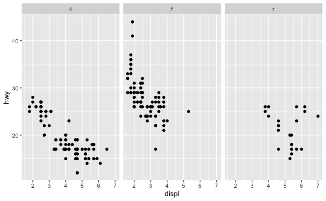

```r
ggplot(data = mpg) +
  geom_point(mapping = aes(x = displ, y = hwy)) +
  facet_wrap(. ~ drv)
```

I would argue it is better to use `facet_wrap(ncol = 1)` or `facet_wrap(nrow = 1)`.

#### **Question 4 - Take this faceted plot. What are the advantages and disadvantages of using faceting instead of color aesthetic?**

```r
ggplot(data = mpg) +
  geom_point(mapping = aes(x = displ, y = hwy)) +
  facet_wrap(~ class, nrow = 2)
```

[output not shown]

**Answer:**

Advantages

- You split up your view. Make it simpler if you have a larger dataset.
- If you have many variables to show, it can be difficult to see differences in shapes and colour.
- If the cases are somehow independent of each other.

Disadvantages

- If you just have a small dataset, it can seem empty.
- Difficult to compare direct values.

#### **Question 5 - What does `nrow` and `ncol` do in facets? And why does not facet_grid() have a `nrow` and `ncol` variable?**

**Answer:** I will need to look at the documentation of facets to figure this out.

```r
?facet_wrap
```

`ncol()` sets number of columns while `nrow()` sets number of rows. It is used if you wish to specify your own rows and columns.

These variables are not needed for `facet_grid()` as this function lays it out in rows and columns dependent on the data/equation selected.

#### **Question 6 - When using `facet_grid()` you should usually put the variable with more unique levels in the columns, why?**

**Answer:** This is probably because it is easier to read if its longer in the column compared to rows.

## 5 - Geometric Objects

### 5.1 - Notes

You make different plots/graphs in R by using different `geoms` (geometric object). These can include:

- geom_point = scatter plot

```r
ggplot(data = mpg) +
  geom_point(mapping = aes(x = displ, y = hwy))
```

[output not shown]

- geom_smooth = line graph

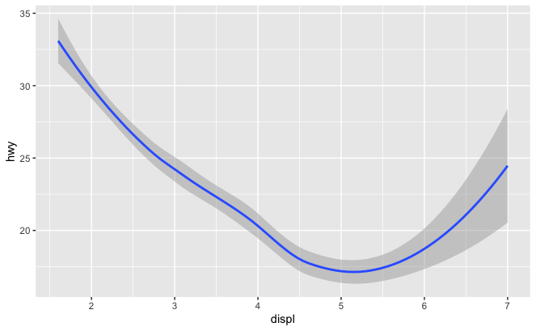

```r
ggplot(data = mpg) +
  geom_smooth(mapping = aes(x = displ, y = hwy))
```

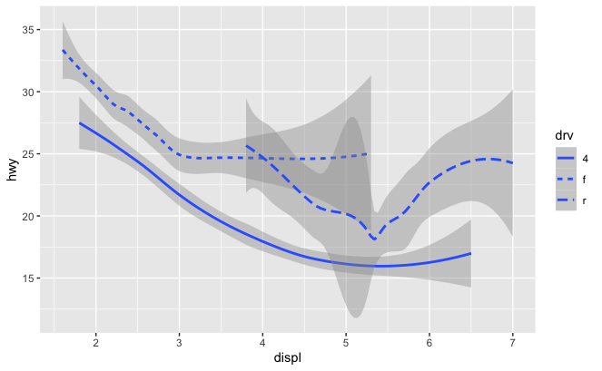

```r
ggplot(data = mpg) +
  geom_smooth(mapping = aes(x = displ, y = hwy, linetype = drv))
```

Here the function separates the car dependent on the drivetrain type (`drv`). We can also do this, and add points to the graph to make it clearer, containing two `geoms` in the same graph, like this.

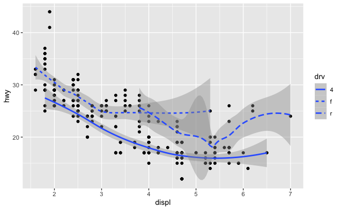

```r
ggplot(data = mpg) +
  geom_point(mapping = aes(x = displ, y = hwy)) +
  geom_smooth(mapping = aes(x = displ, y = hwy, linetype = drv))
```

The problem here is however that you essentially write the code two times. An alternative is to write code like this:

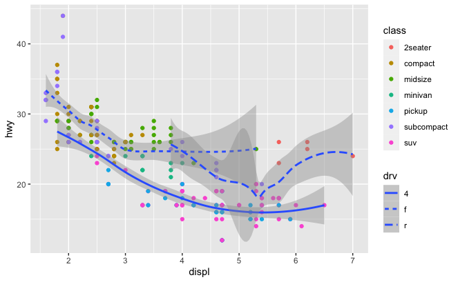

```r
ggplot(data = mpg, mapping = aes(x = displ, y= hwy)) +
  geom_point(mapping = aes(color =class)) +
  geom_smooth(mapping = aes(linetype = drv))
```

Here you can also see that it is possible to place mapping functions inside only one geom and filter data, showing only some of it.

### 5.2 - Exercises

#### **Question 1 - What geom would you use to draw a line chart, boxplot, hisogram, or area chart?**

**Answer;**

The following:

- Linechart = `geom_smooth()`
- Boxplot = `geom_boxplot()`
- Histogram = `geom_histogram()`
- Area chart = `geom_area()`

#### **Question 2 - Run this code in your head. And predict outcome**

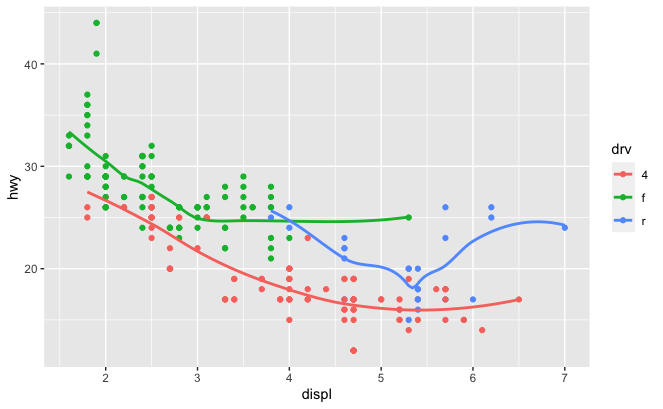

```r
ggplot(data = mpg, mapping = aes(x = displ, y = hwy, color = drv)) +
  geom_point() +
  geom_smooth(se = FALSE)
```

**Answer;** I predict that the below code with make a colored scatter plot of `displ` and `hwy` that is colored according to what type of drivesystem the car has (`drv`). Furthermore, there will be a line graph (w.o. SE) layered on top of this.

#### **Question 3 - What does show.legend = FALSE do? What happens if you remove it?**

**Answer:** It removes the legends box that shows what the different `aesthetics` do.

#### **Question 4 - What does the `SE` argument in `geom_smooth()` do?**

**Answer:** It decides whether there should be a standard error line.

#### **Question 5 - Will these two graphs look different? Why, why not?**

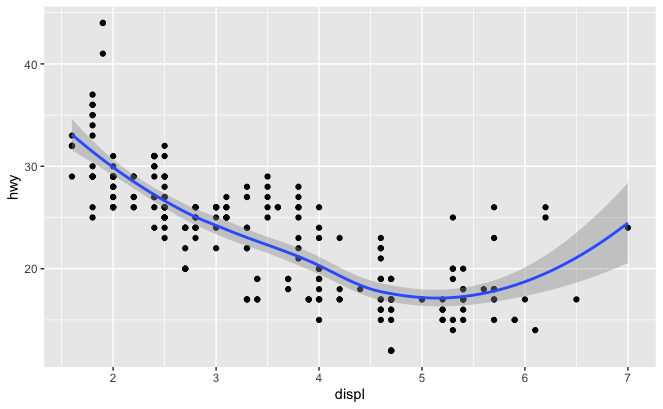

```r
ggplot(data = mpg, mapping = aes(x = displ, y = hwy)) +
  geom_point() +
  geom_smooth()
```

vs

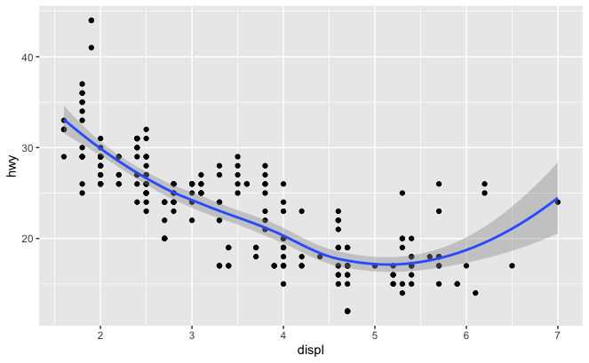

```r
ggplot() +
  geom_point(data = mpg, mapping = aes(x = displ, y = hwy)) +
  geom_smooth(data = mpg, mapping = aes(x = displ, y = hwy))
```

**Answer:** They will going to look exactly the same. The first graph defines mappings and data combined while the second does it individually. Nevertheless, the variables are the identical, hence, the graphs will be identical.

#### **Question 6 - Recreate some R code that generates some plots I see in the book**

**Answer:**

Plot 1.

Here I need a scatter plot of `hwy` and `displ` with a line graph without SE lines (blue).

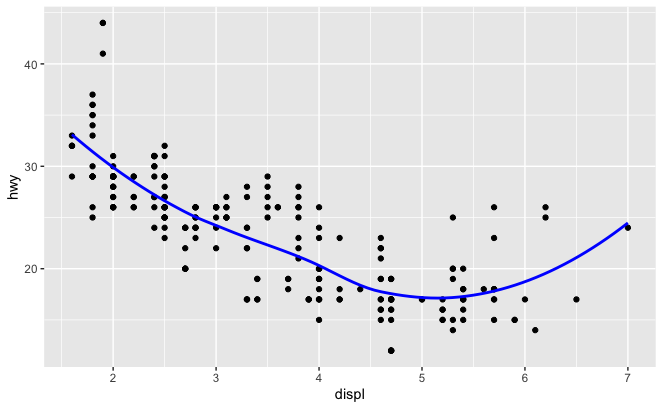

```r
ggplot(data = mpg, mapping = aes(x = displ, y = hwy)) +
  geom_point() +
  geom_smooth(se = FALSE, color = "blue")
```

Plot 2:

Here I need a scatter plot of `hwy` and `displ` with a line graph with group mapping on `drv`. Still without SE lines (blue). Also, as the legend will appear with grouping, I need to set `show.legend = FALSE`.

```r
ggplot(data = mpg, mapping = aes(x = displ, y = hwy)) +
  geom_point() +
  geom_smooth(se = FALSE, color = "blue", aes(group = drv), show.legend = FALSE)
```

[output not shown]

Plot 3:

Here I need a scatter plot of `hwy` and `displ` with aesthetic mapping of coloring on `drv`. Furthermore, I need a line graph with group mapping on `drv` with color. Still without SE lines (blue).

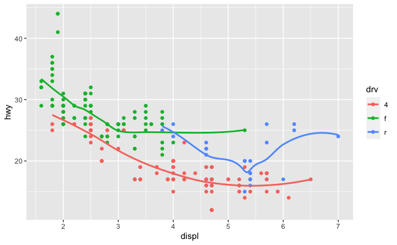

```r
ggplot(data = mpg, mapping = aes(x = displ, y = hwy, color = drv)) +
  geom_point() +
  geom_smooth(aes(group = drv), se = FALSE)
```

Plot 4:

Here I need a scatter plot of `hwy` and `displ` with aesthetic mapping of coloring on `drv`. Furthermore, I need a line graph with the color blue. Still without SE lines (blue).

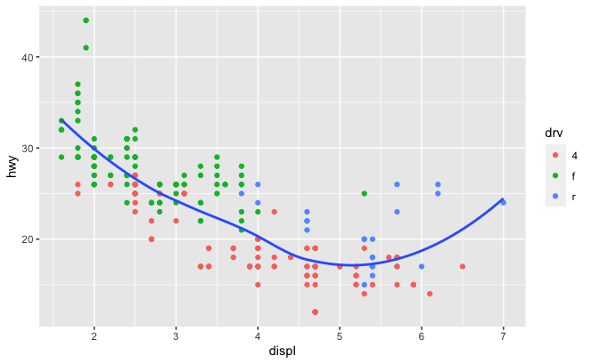

```r
ggplot(data = mpg, mapping = aes(x = displ, y = hwy)) +
  geom_point(aes(color = drv)) +
  geom_smooth(se = FALSE)
```

Plot 5:

Here I need a scatter plot of `hwy` and `displ` with aesthetic mapping of coloring on `drv`. Furthermore, I need a line graph with group mapping on `drv` with `linetype`. Still without SE lines (blue).

```r
ggplot(data = mpg, mapping = aes(x = displ, y = hwy)) +
  geom_point(aes(color = drv)) +
  geom_smooth(se = FALSE, color = "blue", aes(linetype = drv))
```

[output not shown]

Plot 6:

Here I need a scatter plot of `hwy` and `displ` with aesthetic mapping of coloring on `drv`.

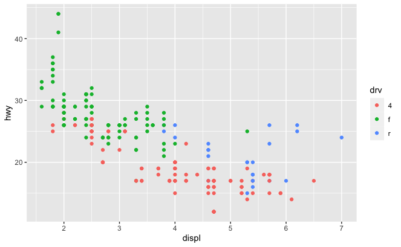

```r
ggplot(data = mpg, mapping = aes(x = displ, y = hwy, color = drv)) +
  geom_point()
```

```r
NA
```